# Practice Activity 9.1

Author

Kabir Wagle

Published

December 1, 2023

```python
import sklearn
import pandas as pd
import numpy as np
```

```python
from sklearn.pipeline import Pipeline
from sklearn.preprocessing import StandardScaler, OneHotEncoder, PolynomialFeatures
from sklearn.linear_model import LinearRegression, Ridge, Lasso, ElasticNet
from sklearn.model_selection import train_test_split
from sklearn.metrics import r2_score, mean_squared_error, accuracy_score
from sklearn.metrics import precision_recall_fscore_support, confusion_matrix, classification_report
from sklearn.metrics import roc_curve, auc
from sklearn.compose import ColumnTransformer, make_column_selector
from sklearn.model_selection import GridSearchCV, cross_val_score, cross_val_predict
from sklearn.neighbors import KNeighborsRegressor, KNeighborsClassifier
from sklearn.tree import DecisionTreeClassifier, DecisionTreeRegressor
from sklearn.linear_model import LogisticRegression
from sklearn.discriminant_analysis import LinearDiscriminantAnalysis
from sklearn.svm import SVC
```

## The Data

At this link, you will find a dataset containing information about heart disease patients: https://www.dropbox.com/scl/fi/0vrpdnq5asmeulc4gd50y/ha_1.csv?rlkey=ciisalceotl77ffqhqe3kujzv&dl=1

A description of the original dataset can be found here: https://archive.ics.uci.edu/dataset/45/heart+disease (However, this dataset has been cleaned and reduced, and the people have been given fictious names.)

```python
df = pd.read_csv('ha_1.csv')
df.head()
```

|  | Name | age | sex | cp | trtbps | chol | restecg | thalach | diagnosis |
| --- | --- | --- | --- | --- | --- | --- | --- | --- | --- |
| 0 | Magnolia Cassin | 60 | 1 | 1 | 117 | 230 | 1 | 160 | No Disease |
| 1 | Dr. Cathern Heathcote | 60 | 0 | 3 | 102 | 318 | 1 | 160 | Disease |
| 2 | Miles Wolf | 62 | 0 | 3 | 130 | 263 | 1 | 97 | No Disease |
| 3 | Mikaila Block | 43 | 1 | 1 | 115 | 303 | 1 | 181 | Disease |
| 4 | Mrs. Jacquline Marquardt | 66 | 1 | 1 | 120 | 302 | 0 | 151 | Disease |

```python
#Universal Column Transformer

ct = ColumnTransformer(
    [("dm", OneHotEncoder(sparse_output = False, handle_unknown = 'ignore'),
      make_column_selector(dtype_include = object)),
     ("st", StandardScaler(),
      make_column_selector(dtype_include = np.number))],
    remainder = "drop"
).set_output(transform = "pandas")
#ct.fit_transform(X)
```

## 1. Logistic Regression

Fit a Logistic Regression using only `age` and `chol` (cholesterol) as predictors.

For a 55 year old, how high would their cholesterol need to be for the doctors to predict heart disease is present?

How high for the doctors to estimate a 90% chance that heart disease is present?

```python
X = df[['age', 'chol']]
y = df['diagnosis']

log_pipeline = Pipeline(
    [("preprocessing", ct),
     ("log", LogisticRegression())])

log_pipeline.fit(X, y)

y_pred = log_pipeline.predict(X)

data = pd.DataFrame({'age': [55], 'chol': [370]})
log_pipeline.predict_proba(data)[:, 1]
```

```
array([0.50090888])
```

```python
data = pd.DataFrame({'age': [55], 'chol': [1586]})
log_pipeline.predict_proba(data)[:, 1]
```

```
array([0.90010294])
```

## 2. Linear Discriminant Analysis

Fit an LDA model using only `age` and `chol` (cholesterol) as predictors.

For a 55 year old, how high would their cholesterol need to be for the doctors to predict heart disease is present?

```python
X = df[['age', 'chol']]
y = df['diagnosis']

lda_pipeline = Pipeline(
    [("preprocessing", ct),
     ("lda", LinearDiscriminantAnalysis())])

lda_pipeline.fit(X, y)

threshold = 0.50
chol = 0
predicted_prob = 0

while predicted_prob < threshold:
    chol += 1
    data = pd.DataFrame({'age': [55], 'chol': [chol]})
    predicted_prob = lda_pipeline.predict_proba(data)[:, 1]

chol
```

```
369
```

## 3. Support Vector Classifier

Fit an SVC model using only `age` and `chol` as predictors. Don’t forget to tune the regularization parameter.

For a 55 year old, how high would their cholesterol need to be for the doctors to predict heart disease is present?

```python
def tune_sv(parameter):

    X = df[['age', 'chol']]
    y = df['diagnosis']

    svc_pipeline = Pipeline(
    [("preprocessing", ct),
     ("sv", SVC(C = parameter, kernel = 'linear', probability = True))])

    svc_pipeline.fit(X, y)
    y_pred_cv = cross_val_predict(svc_pipeline, X, y, cv = 5, method = 'predict')
    accuracy = accuracy_score(y, y_pred_cv)

    return accuracy

parameter_values = [1, 5, 10, 15]

columns = ['Parameter', 'Accuracy']
tune_df = pd.DataFrame(columns = columns)
for p in parameter_values:
    acc = tune_sv(p)
    row = {'Parameter': p, 'Accuracy': acc}
    row = pd.DataFrame([row])
    tune_df = pd.concat([tune_df, row], ignore_index = True)

tune_df
```

|  | Parameter | Accuracy |
| --- | --- | --- |
| 0 | 1 | 0.578431 |
| 1 | 5 | 0.578431 |
| 2 | 10 | 0.598039 |
| 3 | 15 | 0.598039 |

```python
X = df[['age', 'chol']]
y = df['diagnosis']

svc_pipeline = Pipeline(
    [("preprocessing", ct),
     ("sv", SVC(C = 10, kernel = 'linear', probability = True))])

svc_pipeline.fit(X, y)

threshold = 0.50
chol = 0
predicted_prob = 0

while predicted_prob < threshold:
    chol += 1
    data = pd.DataFrame({'age': [55], 'chol': [chol]})
    decision_value = svc_pipeline.decision_function(data)
    predicted_prob = 1 / (1 + np.exp(-decision_value))

chol
```

```
313
```

## 4. Comparing Decision Boundaries

```python
from plotnine import ggplot, aes, geom_point, geom_line, geom_histogram, geom_bar, labs, geom_smooth, facet_wrap
from plotnine import guide_legend, ggtitle, theme_minimal, guides, element_text, scale_color_manual, geom_abline
```

```python
X = df[['age', 'chol']]
y = df['diagnosis']

log_pipeline.fit(X, y)
log_values = log_pipeline.decision_function(X)
df['log_prob'] = 1 / (1 + np.exp(-log_values))

lda_pipeline.fit(X, y)
lda_values = lda_pipeline.decision_function(X)
df['lda_prob'] = 1 / (1 + np.exp(-lda_values))

svc_pipeline.fit(X, y)
svc_values = svc_pipeline.decision_function(X)
df['svc_prob'] = 1 / (1 + np.exp(-svc_values))

df.head()
```

|  | Name | age | sex | cp | trtbps | chol | restecg | thalach | diagnosis | log_prob | lda_prob | svc_prob |
| --- | --- | --- | --- | --- | --- | --- | --- | --- | --- | --- | --- | --- |
| 0 | Magnolia Cassin | 60 | 1 | 1 | 117 | 230 | 1 | 160 | No Disease | 0.495024 | 0.496348 | 0.504992 |
| 1 | Dr. Cathern Heathcote | 60 | 0 | 3 | 102 | 318 | 1 | 160 | Disease | 0.534675 | 0.535660 | 0.584468 |
| 2 | Miles Wolf | 62 | 0 | 3 | 130 | 263 | 1 | 97 | No Disease | 0.532781 | 0.534337 | 0.566898 |
| 3 | Mikaila Block | 43 | 1 | 1 | 115 | 303 | 1 | 181 | Disease | 0.339117 | 0.337280 | 0.308236 |
| 4 | Mrs. Jacquline Marquardt | 66 | 1 | 1 | 120 | 302 | 0 | 151 | Disease | 0.595082 | 0.597147 | 0.661310 |

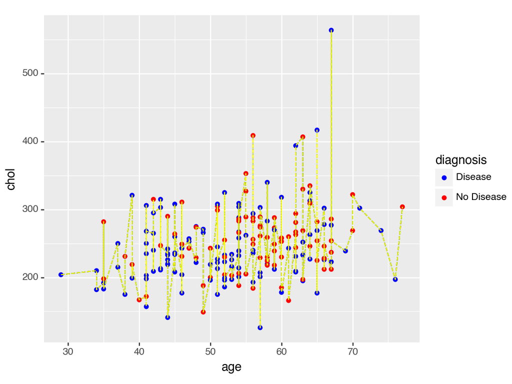

```
<Figure Size: (640 x 480)>
```

```python
(ggplot(df, aes(x='age', y='chol', color='diagnosis'))
+ geom_point()
+ geom_line(aes(intercept = 0, slope = 'log_prob'), linetype = 'dashed', color = 'black')
+ geom_line(aes(intercept = 0, slope = 'lda_prob'), linetype = 'dashed', color = 'green')
+ geom_line(aes(intercept = 0, slope = 'svc_prob'), linetype = 'dashed', color = 'yellow')
+ scale_color_manual(values=['blue', 'red'])
)
```